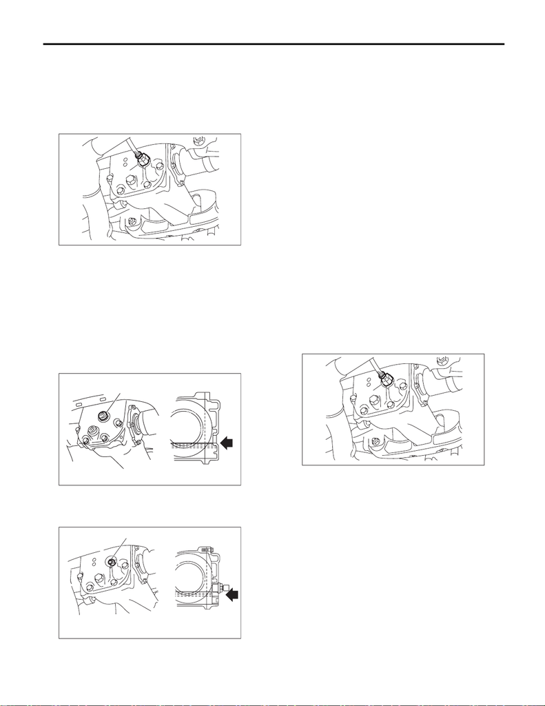

DI-16

Differential Gear Oil

DIFFERENTIALS

2. Differential Gear Oil

A: INSPECTION

1) Disconnect the ground cable from battery.

2) Lift up the vehicle.

4) Remove the filler plug or the oil temperature sen-

sor, and then check the gear oil. Replace the gear

oil if it is contaminated, deteriorated or cloudy. <Ref.

to DI-16, REPLACEMENT, Differential Gear Oil.>

5) Check that the gear oil level is within –5 mm (–0.2

in) from the bottom of the filler plug hole. If the level

is low, make sure that there is no oil leakage and re-

fill up to the bottom of filler plug hole.

• T-type (B1, B2)

• T-type (H5)

6) Install the filler plug or the oil temperature sen-

sor.

NOTE:

• Degrease the thread portion of B1 and B2 suffi-

ciently and apply liquid gasket to the filler plug.

Liquid gasket:

THREE BOND 1105 (Part No. 004403010) or

equivalent

• Use a new gasket for H5.

Tightening torque:

B1, B2

49 N·m (5.0 kgf-m, 36.1 ft-lb)

H5

60 N·m (6.1 kgf-m, 44.3 ft-lb)

B: REPLACEMENT

CAUTION:

• Gear oil is extremely hot just after driving. Be

wary of receiving burns.

• Be careful not to spill the differential gear oil

on exhaust pipe. If gear oil is spilled, wipe it off

completely.

1) Disconnect the ground cable from battery.

2) Lift up the vehicle.

3) Disconnect the oil temperature sensor connec-

tor. (T-type (H5))

(A) Oil temperature sensor connector

(A) Filler plug

(A) Oil temperature sensor

DI-00991

DI-00711

(A)

DI-00992

(A)

(A) Oil temperature sensor connector

DI-00991

(A)

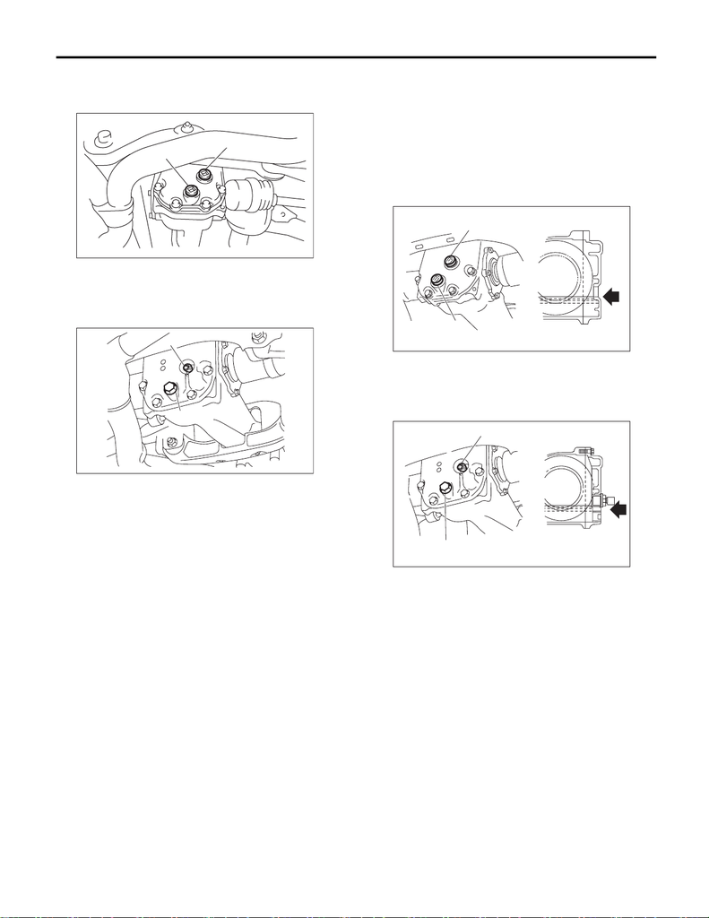

DI-17

Differential Gear Oil

DIFFERENTIALS

4) Remove the drain plug and filler plug or the oil

temperature sensor, and drain the gear oil.

• T-type (B1, B2)

• T-type (H5)

5) Install the drain plug.

NOTE:

• Degrease the thread portion of B1 and B2 suffi-

ciently and apply liquid gasket to the filler plug.

Liquid gasket:

THREE BOND 1105 (Part No. 004403010) or

equivalent

• Use a new gasket for H5.

Tightening torque:

B1, B2

49 N·m (5.0 kgf-m, 36.1 ft-lb)

H5

60 N·m (6.1 kgf-m, 44.3 ft-lb)

6) Fill the differential carrier with gear oil to the bot-

tom of filler plug hole or the oil temperature sensor

hole.

NOTE:

Carefully refill gear oil while watching the level. Ex-

cessive or insufficient oil must be avoided.

Recommended gear oil:

<Ref. to DI-2, SPECIFICATION, General De-

scription.>

Oil capacity:

B1, B2

0.8 L (0.8 US qt, 0.7 Imp qt)

H5

1.0 L (1.1 US qt, 0.9 Imp qt)

• T-type (B1, B2)

• T-type (H5)

7) Install the filler plug or the oil temperature sensor.

NOTE:

• Degrease the thread portion of B1 and B2 suffi-

ciently and apply liquid gasket to the filler plug.

Liquid gasket:

THREE BOND 1105 (Part No. 004403010) or

equivalent

• Use a new gasket for H5.

Tightening torque:

B1, B2

49 N·m (5.0 kgf-m, 36.1 ft-lb)

H5

60 N·m (6.1 kgf-m, 44.3 ft-lb)

(A) Filler plug

(B) Drain plug

(A) Oil temperature sensor

(B) Drain plug

DI-00356

(A)

(B)

DI-00993

(A)

(B)

(A) Filler plug

(B) Drain plug

(A) Oil temperature sensor

(B) Drain plug

DI-00994

(A)

(B)

DI-00995

(A)

(B)